# Nonparametric Regression and Density Estimation

Ron Barry

2025-07-24

# Kernel Density Estimation:

**latticeDensity** is designed to produce density maps accounting for the effects of boundaries and holes. The minimum data needed to perform density estimation in **latticeDensity** is two 2-column matrices. One gives the vertices of a polygon (clockwise around the interior) and the other the Easting and Northing locations of the observations. Note that an observation outside the boundary polygon is moved automatically to the nearest location inside the polygon.

### Step One:

The function nodeFilling takes a polygon representing, in this case, a lake with a causeway and no islands (“holes”“) and fills the region with a grid of equally-spaced nodes. You should select node_spacing to be small, bound only by the speed of processing the data. With small node_spacing, this analysis closely approximates a diffusion.

```r
plot.new()
data(polygon1)
head(polygon1)
```

```
#>           [,1]      [,2]
#> [1,] 0.6421053 0.8132050
#> [2,] 0.6845247 0.4814305
#> [3,] 0.7057345 0.2858322
#> [4,] 0.6696779 0.2066025
#> [5,] 0.5190888 0.1892710
#> [6,] 0.5445405 0.4145805
```

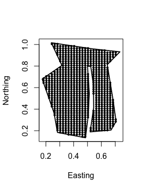

```r
nodeFillingOutput <- nodeFilling(poly=polygon1, node_spacing=0.02)
plot(nodeFillingOutput)
```

## Step Two:

Now for the fun part. The function **formLattice** will ‘connect the dots’ to create a neighbor structure on the nodes. Neighbors are defined to be locations to the N, NE, E, SE, S, SW, W, and NW of each node (as long as there IS a node in that direction). You can examine a plot of the resulting object to see if all regions that should be connected are and that nodes, for instance, across a causeway are not connected.

[figure not shown]

```r
formLatticeOutput <- formLattice(nodeFillingOutput)
plot(formLatticeOutput)
```

## Optional Step:

If you see links that you would like to remove (for instance, a link crosses a boundary), or see links that you would like to add, use the function **editLattice**.

## Step Three:

Just for this example I’ll use the function **csr** from the package **splancs** to simulate a completely random point process with all observations to the east of the causeway removed. Then I’ll feed that into **crossvalDensity**:

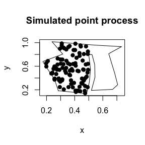

```r
Pointdata <- splancs::csr(polygon1,150)
colnames(Pointdata) <- c("x","y")
Pointdata <- Pointdata[Pointdata[,1]<0.5,]
full_polygon <- rbind(polygon1,polygon1[1,])
colnames(full_polygon) <- c("x","y")
plot(full_polygon,type="l",plt=c(0,1,0,1))
title("Simulated point process")
points(Pointdata,pch=19)
```

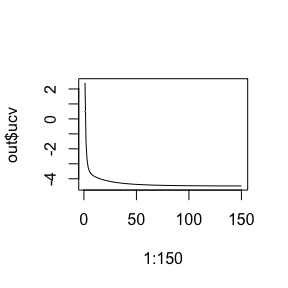

```r
out <- crossvalDensity(formLatticeOutput,PointPattern=Pointdata,
  M=0.5,max_steps = 150)
plot(1:150,out$ucv,type="l")
```

```r
out$k
```

```
#> [1] 150
```

The minimum uvc (Unbiased CrossValidation criterion of Sain, Baggerly and Scott (1994)) was at 150 steps. I’ll use that many steps to get a final, smooth density estimate using **createDensity**.

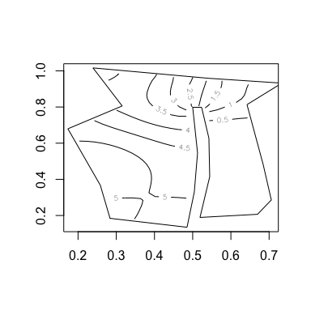

```r
densityOut <- createDensity(formLatticeOutput,
  PointPattern=Pointdata, k=out$k,intensity=FALSE, sparse = TRUE)
plot(densityOut)
```

For the ecologically-inclined, the function **homerange** computes the area of the 95% confidence region.

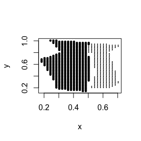

```
#> Proportion of region in homerange =  0.6531863
#> Area of homerange =  0.2118773
```

```r
homerange(densityOut, percent=0.95)
```

### A Simple Kernel Example

To illustrate the concept of kernels based on random walks, I’ll just compute the kernel for a simple network of nodes:

Step One:

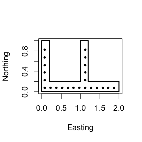

```r
x_poly = c(0, 0, 0.2, 0.2, 1, 1, 1.2, 1.2, 2, 2, 0)
y_poly = c(0, 1, 1, 0.2, 0.2, 1, 1, 0.2, 0.2, 0, 0)
polyg <- cbind(x_poly, y_poly)
nodeFillingOutput <- nodeFilling(polyg, node_spacing=0.15)
plot(nodeFillingOutput)
```

I’ll sometimes refer to specific nodes, so for this illustration I’ll give them names:

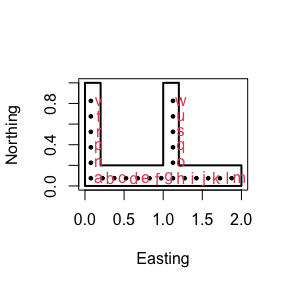

```r
plot(nodeFillingOutput)
text(nodeFillingOutput$nodes+rep(c(0.1,0),each=23),col=2,labels=letters[1:23])
```

Step Two: Create the lattice.

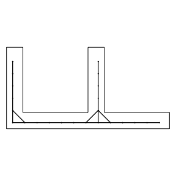

```r
flo <- formLattice(nodeFillingOutput)
plot(flo)
```

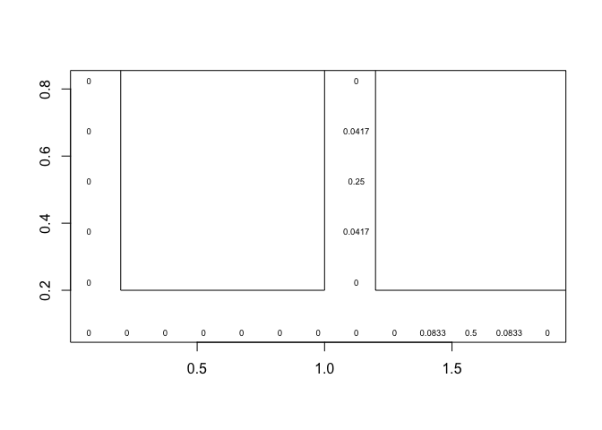

```r
PD = rbind(c(1.5,0.1),c(1.6,0.1),c(1.1,0.5))
out <- createDensity(flo,PointPattern=PD,
  M=0.5, k=1)
plot(out)
text(out$nodes, labels=round(out$probs,4),cex=0.6)
```

I’ll go over this plot carefully. Note that we start with a density of 2/3 at node ‘k’ and 1/3 at node ‘s’, since those nodes are closest to the data locations. With M = 0.5 and a maximum (in this unusual case, since all the nodes are boundary nodes) of four neighbors (see node ‘o’), the flow rate is $0.5/4 = 0.125$ in all links. With $k = 1$, we see that there is now density $0.125*(1/3) = 0.0417$ at nodes ‘u’ and ‘q’, and density $0.125*(2/3) = 0.0833$ at nodes ‘j’ and ‘l’. Now have the distribution of a single-step random walk.

After many steps we will have a (nearly) uniform distribution of probabilities across the entire set of nodes:

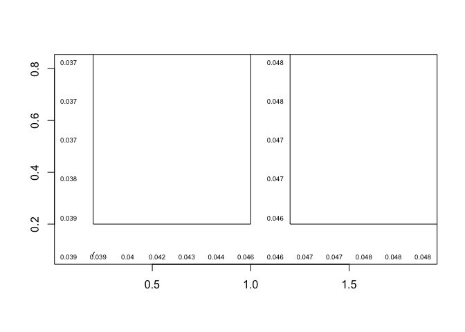

```r
out <- createDensity(flo,PointPattern=PD,
  M=0.5, k=600)
plot(out)
text(out$nodes, labels=round(out$probs,3),cex=0.6)
```

# Nonparametric Regression:

The density obtained from the **latticeDensity** smoother starting from a single observation is a bona fide probability distribution. These can be used as kernels for non-parametric surface estimation, using the Nadaraya-Watson estimator, which basically gets a prediction at each location by taking a weighted average of all observations, weighted by the value of the kernel started from the location of each observation. For a full disussion, see McIntyre and Barry (A Lattice-Based Smoother for Regions with Irregular Boundaries and Holes, Journal of Computational and Graphical Statistics, 2018, Vol. 27, pp. 360 - 367). All the user has to do is supply a polygonal boundary, observed values and their locations.

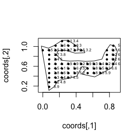

```r
data(nparExample)
attach(nparExample)
plot.new()
#  Simulate a response variable
index1 = (grid2[,2]<0.8)|(grid2[,1]>0.6)
Z = rep(NA,length(grid2[,1]))
n1 = sum(index1)
n2 = sum(!index1)
Z[index1] <- 3*grid2[index1,1] + 4 + rnorm(n1,0,sd=0.4)
Z[!index1] <- -2*grid2[!index1,1] + 4 + rnorm(n2,0,sd=0.4)
#
coords=rbind(polygon2,polygon2[1,])
plot(coords,type="l")
points(grid2,pch=19,cex=0.5,xlim=c(-0.1,1))
text(grid2,labels=round(Z,1),pos=4,cex=0.5)
```

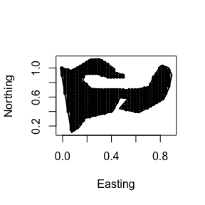

```r
nodeFillingOutput <- nodeFilling(poly=polygon2, node_spacing=0.025)
plot(nodeFillingOutput)
```

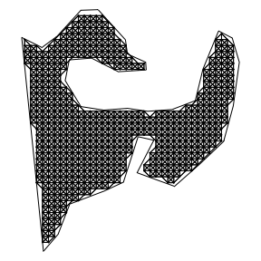

```r
formLatticeOutput <- formLattice(nodeFillingOutput)
plot(formLatticeOutput)
```

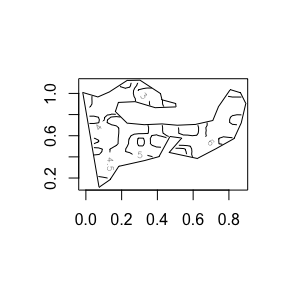

```r
NparRegOut <- createNparReg(formLatticeOutput,Z,PointPattern=grid2,k=4)
plot(NparRegOut)
```

```r
names(NparRegOut)
```

```
#>  [1] "EW_locs"      "NS_locs"      "nodes"        "boundaryPoly" "hole_list"
#>  [6] "PointPattern" "which_nodes"  "NparRegNum"   "NparRegDenom" "NparRegMap"
#> [11] "sigma2"
```

### Error map

You can also plot a countour map of spatial standard errors based on the Nadaraya-Watson kernel regression variance estimator. To do this, use the functions **varianceMap** and **plot.varianceMapOut**. Note that the standard error is not necessarily a good measure of mean squared prediction error, as the kernel estimator (especially when extrapolating in a part of the region far from the observations) can be biased.

```r
varianceMapOut <- varianceMap(formLatticeOutput,Z,PointPattern=grid2,k=20)
```

[figure not shown]

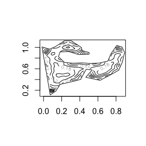

```r
plot(varianceMapOut)
```

### Holes

Islands inside of lakes and other ‘holes’ are easily accomodated in latticeDensity. Each polygonal hold is stored in a different object, then the corresponding nodes are cut out of the irregular region in the nodeFilling function.

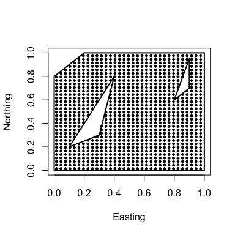

```r
boundary <- cbind(c(0,0,0.2,1,1),c(0,0.8,1,1,0))
hole1 <- cbind(c(0.1,0.3,0.4),c(0.2,0.3,0.8))
hole2 <- cbind(c(0.8,0.9,0.9),c(0.6,0.7,0.95))
region <- nodeFilling(poly = boundary, node_spacing = 0.03, hole_list = list(hole1, hole2))
plot(region)
```

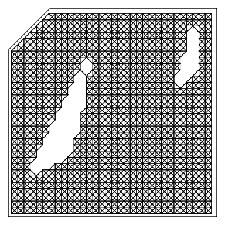

```r
lattice_output = formLattice(region)
plot(lattice_output)
```

There are some links that are crossing the islands, but the function editLattice can be used to remove these.

## NOTE: Warnings

Occasionally the message

`validspamobject()` is deprecated. Use `validate_spam()` directly

will occur. This is generated by the **spam** package or packages that call **spam** and does not seem to have an effect on the output of **latticeDensity**.

Also, expect that some functions (**crossvalidation** or **deletedResid**, for instance) will not run properly if you only have one or two observations.

In a similar vein, crossvalidation often seems to undersmooth data when the observations are in clusters, a common problem with spatial crossvalidation in any context. If you think the optimum number of steps (k) under crossvalidation is too low, just use a larger value of k and examine the deleted sums of squared errors to see that they don’t increase too much.